# Python Term Project

Uğurcan Kalenderoğlu

## Football Data Analysis: How Big European Leagues Differs and What Drives Success?

### Introduction

Football industry has been grown fast and attractiveness of the game becomes more important in order to survive in such a financially-hard-to-survive environment. You should keep fans to support you, sponsors to finance you and players to prefer your.

So how key figures differ in 5 big leagues? What are the main differences between them? Analyzing the key data on these leagues can give some answers to get overview of statistics from these these 5 leagues and how leadership journey is competitive across them.

Explanation of dataset directly from kaggle:

The dataset provides a granular view of 9,074 games, totaling 941,009 events from the biggest 5 European football (soccer) leagues: England, Spain, Germany, Italy, France from 2011/2012 season to 2016/2017 season as of 25.01.2017. There are games that have been played during these seasons for which I could not collect detailed data. Overall, over 90% of the played games during these seasons have event data.

The dataset is organized in 3 files:

events.csv contains event data about each game. Text commentary was scraped from: bbc.com, espn.com and onefootball.com ginf.csv - contains metadata and market odds about each game. odds were collected from oddsportal.com dictionary.txt contains a dictionary with the textual description of each categorical variable coded with integers [https://www.kaggle.com/secareanualin/football-events/home]

### Data Wrangling

#### Data Reading

Before starting to exploratary data analysis, we should install required packages.

```python
#Loading required packages
import pandas as pd
import numpy as np
import matplotlib.pyplot as plt
```

```python
#Read and Get Shape of Events Data
events = pd.read_csv('events.csv')
events.shape
```

```
(941009, 22)
```

There are 941k rows and 22 variables in events data frame

```python
#Read and Get Shape of Games Data
games = pd.read_csv('ginf.csv')
games.shape
```

```
(10112, 18)
```

It's smaller data frame compared to events with more than 10k rows and 18 variables in total

It's important to understand coverage of data and eliminate the unnecessary part for the rest of the analysis. It will also save time when getting output of codes. Let's try to understand which dimensions included in data tables and time period for the whole dataset.

```python
events.head()
```

|  | id_odsp | id_event | sort_order | time | text | event_type | event_type2 | side | event_team | opponent | ... | player_in | player_out | shot_place | shot_outcome | is_goal | location | bodypart | assist_method | situation | fast_break |
| --- | --- | --- | --- | --- | --- | --- | --- | --- | --- | --- | --- | --- | --- | --- | --- | --- | --- | --- | --- | --- | --- |
| 0 | UFot0hit/ | UFot0hit1 | 1 | 2 | Attempt missed. Mladen Petric (Hamburg) left f... | 1 | 12.0 | 2 | Hamburg SV | Borussia Dortmund | ... | NaN | NaN | 6.0 | 2.0 | 0 | 9.0 | 2.0 | 1 | 1.0 | 0 |
| 1 | UFot0hit/ | UFot0hit2 | 2 | 4 | Corner, Borussia Dortmund. Conceded by Dennis... | 2 | NaN | 1 | Borussia Dortmund | Hamburg SV | ... | NaN | NaN | NaN | NaN | 0 | NaN | NaN | 0 | NaN | 0 |
| 2 | UFot0hit/ | UFot0hit3 | 3 | 4 | Corner, Borussia Dortmund. Conceded by Heiko ... | 2 | NaN | 1 | Borussia Dortmund | Hamburg SV | ... | NaN | NaN | NaN | NaN | 0 | NaN | NaN | 0 | NaN | 0 |
| 3 | UFot0hit/ | UFot0hit4 | 4 | 7 | Foul by Sven Bender (Borussia Dortmund). | 3 | NaN | 1 | Borussia Dortmund | Hamburg SV | ... | NaN | NaN | NaN | NaN | 0 | NaN | NaN | 0 | NaN | 0 |
| 4 | UFot0hit/ | UFot0hit5 | 5 | 7 | Gokhan Tore (Hamburg) wins a free kick in the ... | 8 | NaN | 2 | Hamburg SV | Borussia Dortmund | ... | NaN | NaN | NaN | NaN | 0 | 2.0 | NaN | 0 | NaN | 0 |

5 rows × 22 columns

```python
games.head()
```

|  | id_odsp | link_odsp | adv_stats | date | league | season | country | ht | at | fthg | ftag | odd_h | odd_d | odd_a | odd_over | odd_under | odd_bts | odd_bts_n |
| --- | --- | --- | --- | --- | --- | --- | --- | --- | --- | --- | --- | --- | --- | --- | --- | --- | --- | --- |
| 0 | UFot0hit/ | /soccer/germany/bundesliga-2011-2012/dortmund-... | True | 2011-08-05 | D1 | 2012 | germany | Borussia Dortmund | Hamburg SV | 3 | 1 | 1.56 | 4.41 | 7.42 | NaN | NaN | NaN | NaN |
| 1 | Aw5DflLH/ | /soccer/germany/bundesliga-2011-2012/augsburg-... | True | 2011-08-06 | D1 | 2012 | germany | FC Augsburg | SC Freiburg | 2 | 2 | 2.36 | 3.60 | 3.40 | NaN | NaN | NaN | NaN |
| 2 | bkjpaC6n/ | /soccer/germany/bundesliga-2011-2012/werder-br... | True | 2011-08-06 | D1 | 2012 | germany | Werder Bremen | Kaiserslautern | 2 | 0 | 1.83 | 4.20 | 4.80 | NaN | NaN | NaN | NaN |
| 3 | CzPV312a/ | /soccer/france/ligue-1-2011-2012/paris-sg-lori... | True | 2011-08-06 | F1 | 2012 | france | Paris Saint-Germain | Lorient | 0 | 1 | 1.55 | 4.50 | 9.40 | NaN | NaN | NaN | NaN |
| 4 | GUOdmtII/ | /soccer/france/ligue-1-2011-2012/caen-valencie... | True | 2011-08-06 | F1 | 2012 | france | Caen | Valenciennes | 1 | 0 | 2.50 | 3.40 | 3.45 | NaN | NaN | NaN | NaN |

There are data for 6 seasons between 2012 and 2017. My analysis will not focus on any time series, so i would prefer to focus on only one season which has widest range of statistics in the events dataset.

#### Data Manipulation

First, i need to combine two dataset using the id_odsp which is unique identifier of the game:

```python
game_events = pd.merge(events,
                games[['id_odsp','country', 'ht','at','season','fthg','ftag']],
                      on='id_odsp')
game_events.head()
```

|  | id_odsp | id_event | sort_order | time | text | event_type | event_type2 | side | event_team | opponent | ... | bodypart | assist_method | situation | fast_break | country | ht | at | season | fthg | ftag |
| --- | --- | --- | --- | --- | --- | --- | --- | --- | --- | --- | --- | --- | --- | --- | --- | --- | --- | --- | --- | --- | --- |
| 0 | UFot0hit/ | UFot0hit1 | 1 | 2 | Attempt missed. Mladen Petric (Hamburg) left f... | 1 | 12.0 | 2 | Hamburg SV | Borussia Dortmund | ... | 2.0 | 1 | 1.0 | 0 | germany | Borussia Dortmund | Hamburg SV | 2012 | 3 | 1 |
| 1 | UFot0hit/ | UFot0hit2 | 2 | 4 | Corner, Borussia Dortmund. Conceded by Dennis... | 2 | NaN | 1 | Borussia Dortmund | Hamburg SV | ... | NaN | 0 | NaN | 0 | germany | Borussia Dortmund | Hamburg SV | 2012 | 3 | 1 |
| 2 | UFot0hit/ | UFot0hit3 | 3 | 4 | Corner, Borussia Dortmund. Conceded by Heiko ... | 2 | NaN | 1 | Borussia Dortmund | Hamburg SV | ... | NaN | 0 | NaN | 0 | germany | Borussia Dortmund | Hamburg SV | 2012 | 3 | 1 |
| 3 | UFot0hit/ | UFot0hit4 | 4 | 7 | Foul by Sven Bender (Borussia Dortmund). | 3 | NaN | 1 | Borussia Dortmund | Hamburg SV | ... | NaN | 0 | NaN | 0 | germany | Borussia Dortmund | Hamburg SV | 2012 | 3 | 1 |
| 4 | UFot0hit/ | UFot0hit5 | 5 | 7 | Gokhan Tore (Hamburg) wins a free kick in the ... | 8 | NaN | 2 | Hamburg SV | Borussia Dortmund | ... | NaN | 0 | NaN | 0 | germany | Borussia Dortmund | Hamburg SV | 2012 | 3 | 1 |

5 rows × 28 columns

In order to decide which season to keep, we should count the number of events per season:

```python
game_events.groupby('season')['id_odsp'].nunique()
```

```
season
2012    1379
2013    1436
2014    1726
2015    1771
2016    1785
2017     977
Name: id_odsp, dtype: int64
```

I can eliminate data of seasons except 2016 as it stores highest number of games per season. There are 1785 matches which has detailed event statistics.

```python
game_events = game_events[game_events['season'] == 2016]
```

Add total goal column by summing full time home goal and away goal.

```python
game_events['totg'] = game_events['fthg'] + game_events['ftag']
```

### Get to Know Data Further & Initial Analysis

#### Comparison of the 5 Leagues

Although 5 leagues are the most popular leagues in the world, there are some difference between them. Comparing key statistics among them would be good starting point to have some hypothesis on each.

First we should understand which league has highest goal per match since for most of the football fans more goals mean more enjoyable times when watching the match. In order to do that we should create new variable which is sum of home and away goals per game:

```python
#Remove the duplicated games
uniq_games = game_events.drop_duplicates('id_odsp')
```

```python
#Remove unnecessary columns
uniq_games = uniq_games[['country', 'totg']]
```

```python
#Group by Country and Calculate sum of total goals & count of games and goal per match in each
f = {'totg': {'sum': 'sum', 'count': 'count'}}

goalpermatch = uniq_games.groupby(['country'], as_index=False).agg(f)
goalpermatch['avggoal'] = round(goalpermatch['totg']['sum'] / goalpermatch['totg']['count'], 2)
```

Let's plot the goal per match statistic per countries:

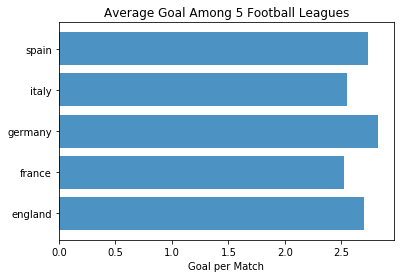

```python
#Bar Chart
objects = ('Python', 'C++', 'Java', 'Perl', 'Scala', 'Lisp')
y_pos = np.arange(len(objects))
performance = [10,8,6,4,2,1]

plt.barh(list(goalpermatch['country']), goalpermatch['avggoal'], align='center', alpha=0.8)
plt.yticks(list(goalpermatch['country']), goalpermatch['country'])
plt.xlabel('Goal per Match')
plt.title('Average Goal Among 5 Football Leagues')

plt.show()
```

As we might see above chart, Germany (Bundesliga) has highest goal per game within 5 big leagues. Italy and France are bottom two leagues in terms of average goal.

Overall, we can say that goal per match does not differ significantly among these 5 leagues.

#### How Distribution of Goal Minutes Differ per League

Although goal per game figures are close to each other, it's important to look at distribution of occurence of these goals during the full time of 90 minutes game.

We have this info within our game_events dataset:

- *is_goal* show that event ended up with scoring or not (1 means that event is finalized as goal)
- *time* indicates that event occured at which minute of the game

It would be useful to break the 90 minutes into time bands rather than looking at discrete values. I think 20 minute breaks would be enough. So our time brackets will be:

- 0-20 min
- 20-40 min
- 40-60 min
- 60-80 min
- 80+ min

Now, what are steps that we need to complete to get this insight from the dataset:

- filter game_events datset to include only rows where is_goal variable is equal to 1
- define new variable which assign 5 time brackes given above to minute variable of original dataset
- group by country and time brackets and count the goals for each
- visualize the results by stacked bar chart

```python
#Step 1
goal_min = game_events[game_events['is_goal'] == 1]
```

```python
#Step 2
goal_min.loc[goal_min['time'] <= 20, 'time_bracket'] = '0-20 min'
goal_min.loc[((goal_min['time'] > 20) & (goal_min['time'] <= 40)), 'time_bracket'] = '20-40 min'
goal_min.loc[((goal_min['time'] > 40) & (goal_min['time'] <= 60)), 'time_bracket'] = '40-60 min'
goal_min.loc[((goal_min['time'] > 60) & (goal_min['time'] <= 80)), 'time_bracket'] = '60-80 min'
goal_min.loc[(goal_min['time'] > 80), 'time_bracket'] = '80+ min'
```

```python
#Step 3
goal_min = goal_min[['country', 'time_bracket']]

goal_min = goal_min.groupby(['country', 'time_bracket']).size() \
  .reset_index(name='count')
```

```python
goal_min = goal_min.pivot(index='country',columns='time_bracket', values='count')
```

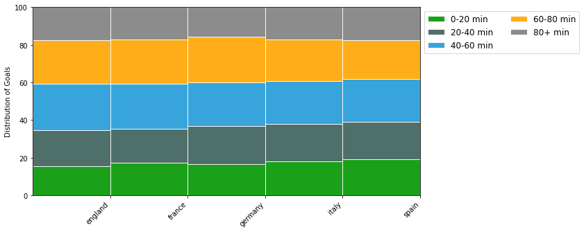

```python
#Step 4 (Thanks to Chris Albon for sharing this readable framework via chrisalbon.com)

# Create a figure with a single subplot
f, ax = plt.subplots(1, figsize=(10,5))

# Set bar width at 1
bar_width = 1

# positions of the left bar-boundaries
bar_l = [i for i in range(len(goal_min['0-20 min']))]

# positions of the x-axis ticks (center of the bars as bar labels)
tick_pos = [i+(bar_width/2) for i in bar_l]

# Create the total score for each brackets
totals = [i+j+k+m+n for i,j,k,m,n in zip(goal_min['0-20 min'], goal_min['20-40 min'], goal_min['40-60 min'], goal_min['60-80 min'],
                                goal_min['80+ min'])]

# Create the percentage of the total score the 0-20 min value for each participant was
pre_rel = [i / j * 100 for  i,j in zip(goal_min['0-20 min'], totals)]

# Create the percentage of the total score the 20-40 min value for each participant was
mid_rel = [i / j * 100 for  i,j in zip(goal_min['20-40 min'], totals)]

# Create the percentage of the total score the 40-60 min value for each participant was
post_rel = [i / j * 100 for  i,j in zip(goal_min['40-60 min'], totals)]

# Create the percentage of the total score the 60-80 min value for each participant was
post2_rel = [i / j * 100 for  i,j in zip(goal_min['60-80 min'], totals)]

# Create the percentage of the total score the 80+ min value for each participant was
post3_rel = [i / j * 100 for  i,j in zip(goal_min['80+ min'], totals)]

a = list(['england', 'france', 'germany', 'italy', 'spain'])

# Create a bar chart in position bar_1
ax.bar(bar_l,
       # using pre_rel data
       pre_rel,
       # labeled
       label='0-20 min',
       # with alpha
       alpha=0.9,
       # with color
       color='#019600',
       # with bar width
       width=bar_width,
       # with border color
       edgecolor='white'
       )

# Create a bar chart in position bar_1
ax.bar(bar_l,
       # using mid_rel data
       mid_rel,
       # with pre_rel
       bottom=pre_rel,
       # labeled
       label='20-40 min',
       # with alpha
       alpha=0.9,
       # with color
       color='#3C5F5A',
       # with bar width
       width=bar_width,
       # with border color
       edgecolor='white'
       )

# Create a bar chart in position bar_1
ax.bar(bar_l,
       # using post_rel data
       post_rel,
       # with pre_rel and mid_rel on bottom
       bottom=[i+j for i,j in zip(pre_rel, mid_rel)],
       # labeled
       label='40-60 min',
       # with alpha
       alpha=0.9,
       # with color
       color='#219AD8',
       # with bar width
       width=bar_width,
       # with border color
       edgecolor='white'
       )

# Create a bar chart in position bar_1
ax.bar(bar_l,
       # using post2_rel data
       post2_rel,
       # with pre_rel and mid_rel on bottom
       bottom=[i+j+k for i,j,k in zip(pre_rel, mid_rel, post_rel)],
       # labeled
       label='60-80 min',
       # with alpha
       alpha=0.9,
       # with color
       color='orange',
       # with bar width
       width=bar_width,
       # with border color
       edgecolor='white'
       )

# Create a bar chart in position bar_1
ax.bar(bar_l,
       # using post3_rel data
       post3_rel,
       # with pre_rel and mid_rel on bottom
       bottom=[i+j+k+m for i,j,k,m in zip(pre_rel, mid_rel, post_rel, post2_rel)],
       # labeled
       label='80+ min',
       # with alpha
       alpha=0.9,
       # with color
       color='grey',
       # with bar width
       width=bar_width,
       # with border color
       edgecolor='white'
       )

# Set the ticks to be first names
plt.xticks(tick_pos, a)
ax.set_ylabel("Distribution of Goals")
ax.set_xlabel("")

# Let the borders of the graphic
plt.xlim([min(tick_pos)-bar_width, max(tick_pos)])
plt.ylim(0, 100)

# rotate axis labels
plt.setp(plt.gca().get_xticklabels(), rotation=45, horizontalalignment='right')
ax.legend(loc="upper left", bbox_to_anchor=(1,1), ncol=2, fontsize='large')

# shot plot
plt.show()
```

Although distribution of goal minutes seems similiar among 5 leagues, there are some time brackets that probability of goal is greater than other minute ranges.

If you have only 20 minutes to allocate the game and you want to maximize to experience live goal moments when you watching;

- between 40th and 60th minutes for England, France, Italy and Spain
- between 60th and 80th minutes for Germany will be safest choices you can make.

Also, it's visible that occurence of goal in earlier minutes is less possible in England than France, in France than Germany, in Germany than Italy, in Italy than Spain.

### Aggressiveness of the Game as Time Passes

It's important to get to know that players becomes more agressive as time get close to the finish?

In order to get this insight, i will plot the distribution of number of cards by time and histogram would be good choice to get picture on that.

Yellow Cards:

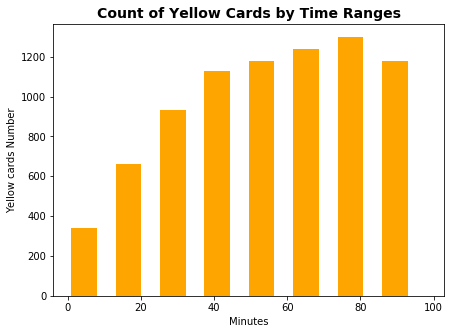

```python
y_card = game_events[game_events['event_type'] == 4]

plt.figure(figsize=(7,5))
plt.hist(y_card.time,width=7,bins=8,color="orange")
plt.xlabel("Minutes")
plt.ylabel("Yellow cards Number")
plt.title("Count of Yellow Cards by Time Ranges",fontsize=14,fontweight="bold")
```

I should mention that to get right figures for red cards, we should also add second_yellow card which is stored separately in the original dataset.

Red Cards:

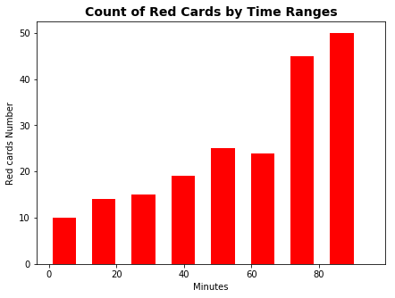

```python
y2_card= game_events[game_events['event_type'] == 5]
r_card = game_events[game_events['event_type'] == 6]
y2_r = [y2_card,r_card]
r_comb = pd.concat(y2_r)

plt.figure(figsize=(7,5))
plt.hist(r_comb.time,width=7,bins=8,color="red")
plt.xlabel("Minutes")
plt.ylabel("Red cards Number")
plt.title("Count of Red Cards by Time Ranges",fontsize=14,fontweight="bold")
```

### Conclusion

Most of the football fans claim that England Premier Leagues is most attractive league in terms of attractiveness of the game and war of physical struggle. Ball is fastly passing middle of the pitch and there are a lot of attacks per match. Our selective dataset shows that Bundesliga has higher goal per match figure than England Premier League but do not forget that our data is not comprehensive enough to claim something bold.

Additionaly we can say that key figures more or less sames across 5 big leagues: England, Spain, France, Italy and Gremany. For instance distribution of goals per minutes peaks between 40th and 60th minutes for most of the leagues, only Germany (Bundesliga) differs with peak at 60th - 80th minute range.

Dataset is really insightful and there are a lot of things that can be derived further. For the purpose of using basic functionality of python, numpy, pandas and matplotlib packages; that's enough for now.